# FPP Chapter 6: Decomposition of Time Series

Timo Meiendresch

27/05/2019

```r
# libraries
library("fpp2")
library("seasonal")
```

# Chapter 6: Time Series decomposition

We think of a time series comprising three components:

- a trend-cycle component
- a seasonal component
- a remainder component (containing anything else in the time series)

How to extract these components and eventually use this to improve the forecast?

Additive decomposition:
$$y_t = S_t + T_t + R_t$$

Multiplicative decomposition:
$$y_t = S_t \times T_t \times R_t$$

- Additive decomposition if the magnitude of the seasonal fluctuations, or variation around trend-cycle, does not vary with the level of the time series.
- Variation around the trend-cycle proportional to the level of the time series, then a multiplicative decomposition is more appropriate

Especially for economic time series multiplicative decompositions are common. Alternatively, transform/stabilize time series first and use additive decomposition (e.g. log transformation is equivalent to using a multiplicative decomposition on the levels).

## Moving averages

First step is to use a moving average method to estimate the trend-cycle

Moving average of order m:
$$\hat{T}_t = \frac{1}{m} \sum_{j=-k}^k y_{t+j}$$

where $m=2k+1$. The estimate of the trend-cycle at time t is obtained by averaging values of the time series within k periods of t. The average eliminates some of the randomness, leaving a smooth trend-cycle component, called m-**MA**, a moving average of order m.

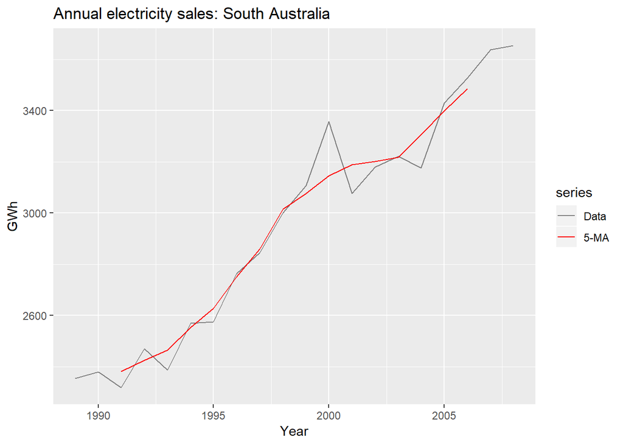

```r
autoplot(elecsales, series="Data") +
  autolayer(ma(elecsales,5), series ="5-MA")+
  xlab("Year") +
  ylab("GWh") +
  ggtitle("Annual electricity sales: South Australia") +
  scale_colour_manual(values=c("Data"="grey50",
                               "5-MA"="red"),
                      breaks=c("Data", "5-MA"))
```

#### Moving average of moving averages

WE can apply a moving average to a moving average making this an even -order moving average symmetric.

When a 2-MA follows a moving average of an even order (such as 4), it is called a “centred moving average of order 4”. This is because the results are now symmetric. To see this, we can write the $2\times4-MA$ as follows:

$$\hat{T}_t = \frac{1}{2} \bigg[\frac{1}{4}(y_{t-2} + y_{t-1} + y_t + y_{t+1}) + \frac{1}{4}(y_{t-1} + y_t + y_{t+1} + y_{t+2}) \bigg]$$

It is now a weighted average of observations that is symmetric.

## Estimating the trend-cycle with seasonal data

Most common use of centred moving averages is for estimating the trend-cycle from seasonal data.

Consider the $2\times 4-MA$ from before. We can rewrite it as:

$$\hat{T}_t = \frac{1}{8} y_{t-2} + \frac{1}{4} y_{t-1} + \frac{1}{4}y_t + \frac{1}{4}y_{t+1} + \frac{1}{8}y_{t+2}$$

When applied to quarterly data, each quarter of the year is given equal weight as the first and last terms apply to the same quarter in consecutive years. Hence, seasonal variation will be averaged out.

Accordingly one should choose the order of MA according to frequency to get rid of the seasonality:

- $2\times8-MA$ or $2\times12-MA$ to quarterly data
- $2\times12-MA$ to estimate the trend-cycle of monthly data
- $7-MA$ to estimate the trend-cycle of daily data with a weekly seasonality.

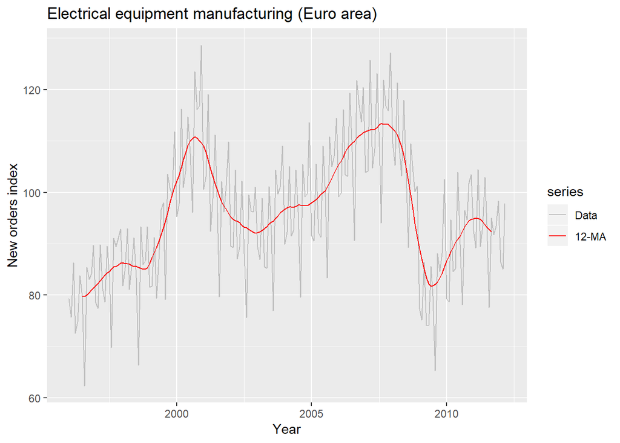

```r
# Example
autoplot(elecequip, series="Data") +
  autolayer(ma(elecequip, 12), series="12-MA") +
  xlab("Year") +
  ylab("New orders index") +
  ggtitle("Electrical equipment manufacturing (Euro area)") +
  scale_colour_manual(values=c("Data"="grey",
                               "12-MA"="red"),
                      breaks=c("Data", "12-MA"))
```

Here, the $2\times12-MA$ is applied and the smooth line shows no seasonality.

## Classical decomposition

#### Multiplicative decomposition

Similar, except that the subtractions are replaced by divisions

- Step 1: (…)

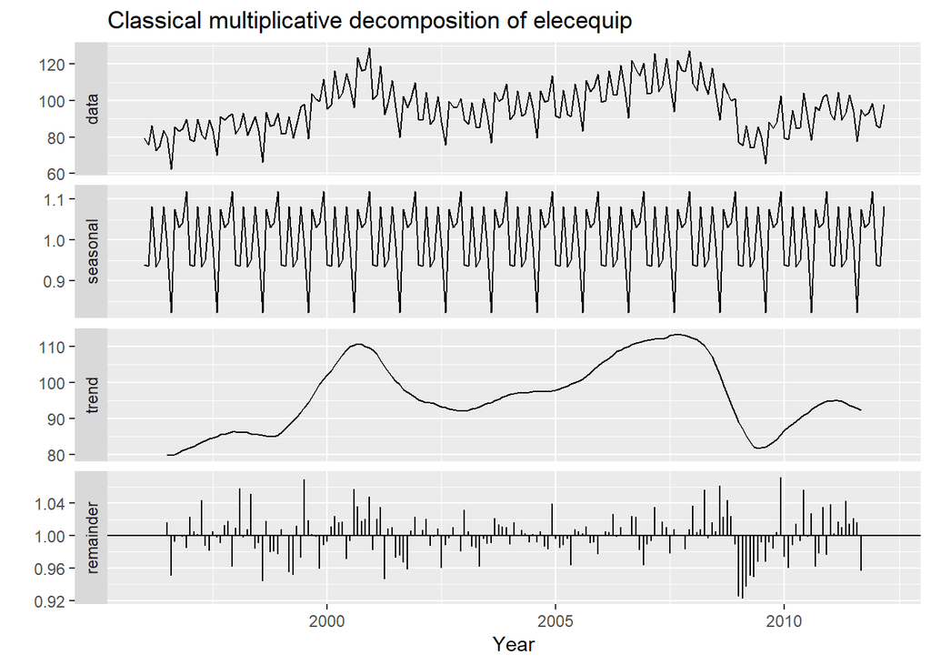

```r
elecequip %>%
  decompose(type="multiplicative") %>%
  autoplot() +
  xlab("Year") +
  ggtitle("Classical multiplicative decomposition of elecequip")
```

#### Notes

- Not recommended, as there are now several much better methods

Problems with classical decomposition:

- Estimate for first few and last few observations not available
- Trend-cycle estimate tends to over-smooth rapid rises and falls in the data
- Assumes seasonal component repeats from year to year which is not always a reasonable assumption (pattern changes)
- Not robust to unusual values

## X11 decomposition

Combination of classical decomposition and some extra steps. Process is automatic and highly robust to outliers and level shifts in the time series. Method is described in Dagum and Bianconcini (2016). The X11 method is available using `seas()` function from the `seasonal` package for R.

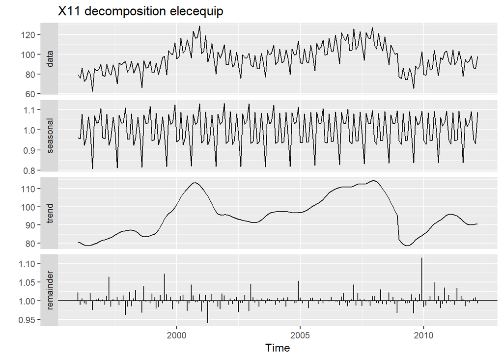

```r
elecequip %>%
  seas(x11="") -> fit

autoplot(fit) +
  ggtitle("X11 decomposition elecequip")
```

- X11 has capture the sudden fall in the data better and the unsual observation at the end of 2009 is now more clearly seen in the remainder component.

Given the output from the `seas()` function:

- `seasonal()`extracts seasonal component
- `trendcycle()` extracts trend-cycle component
- `remainder()` extracts remainder component
- `seasadj()` computes seasonally adjusted ts

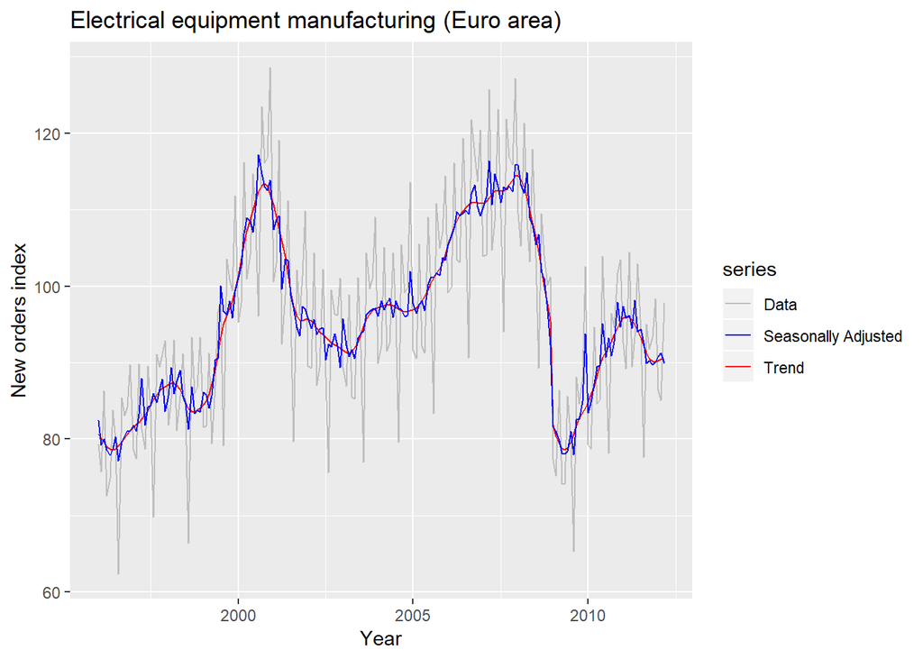

```r
autoplot(elecequip, series="Data") +
  autolayer(trendcycle(fit), series="Trend") +
  autolayer(seasadj(fit), series="Seasonally Adjusted") +
  xlab("Year") + ylab("New orders index") +
  ggtitle("Electrical equipment manufacturing (Euro area)") +
  scale_colour_manual(values=c("gray","blue","red"),
             breaks=c("Data","Seasonally Adjusted","Trend"))
```

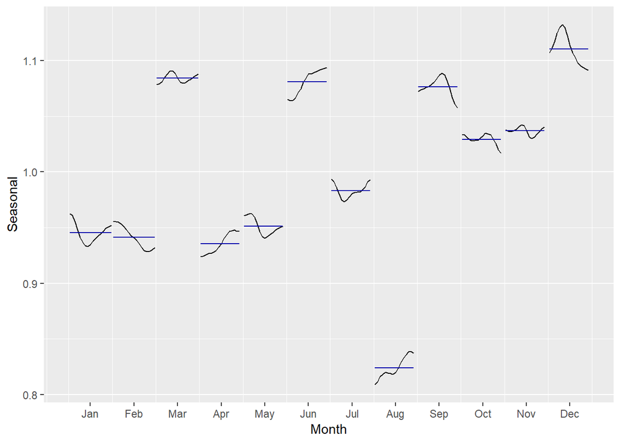

```r
# visualize seasonal component over time
fit %>%
  seasonal() %>%
  ggsubseriesplot() + ylab("Seasonal")
```

## SEATS decomposition

Stands for “Seasonal Extraction in ARIMA Time Series”. Works only with quarterly and monthly data. Discussion of this method is available in Dagum and Bianconcini (2016). Demonstration only

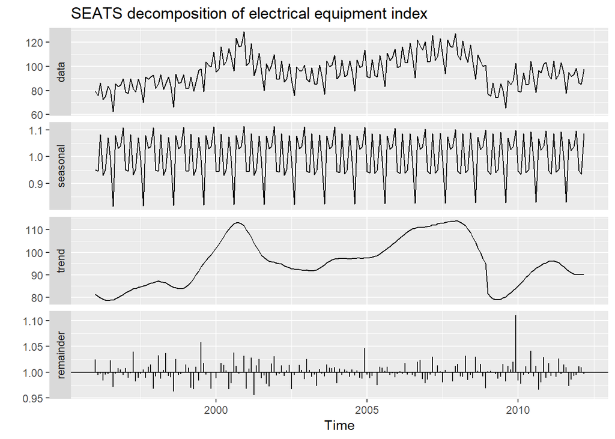

```r
elecequip %>%
  seas() %>%
  autoplot() + ggtitle("SEATS decomposition of electrical equipment index")
```

## STL decomposition

Accronym for “Seasonal and Trend decomposition using Loess”. Loess is a method for estimating nonlinear relationships.

Advantages over classical, SEATS and X11 decomposition methods:

- Handles any type of seasonality, not only monthly and quarterly data
- Seasonal component is allowed to change over time, rate of change can be controlled by the user.
- Smoothness of the trend-cycle can also be controlled by the user.
- Robust to outliers (user can specify a robust decomposition).

STL has some disadvantages:

- Does not handle trading day or calendar variation automatically
- only provides facilities for additive decompositions

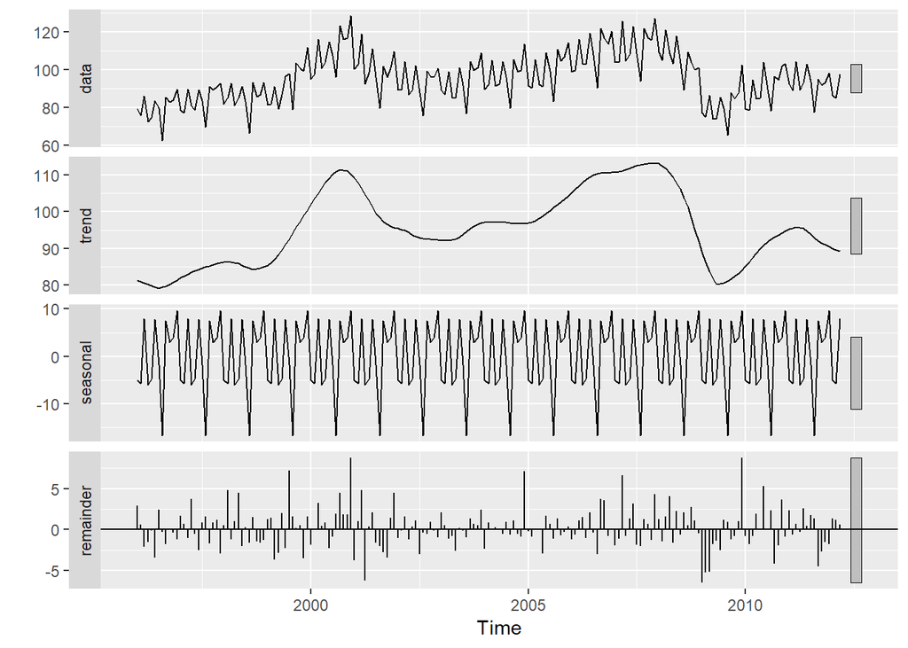

```r
# fixed seasonality
elecequip %>%
  stl(t.window=13, s.window="periodic", robust=T) %>%
  autoplot()
```

Parameters:

- trend-cycle window (`t.window`): Number of consecutive observations to be used when estimating the trend-cycle
- seasonal window (`s.window`): Number of consecutive years to be used in estimating each value in the seasonal component.
- Note that `s.window="periodic", robust=TRUE` implies fixed seasonality.

These control how rapidly the trend-cycle and seasonal components can change. Both should be odd numbers.

`mstl()` function provides a convenient automated STL decomposition using `s.window=13`, and `t.window` also chosen automatically. This usually gives a good balance between overfitting the seasonality and allowing it to slowly change over time. This automatic procedure can be adjusted for some time series. Again, components can be extracted using `seasonal()`, `trendcycle()`, `remainder()` function for the remainder component. The `seasadj()`function can be used to compute the seasonally adjusted series.

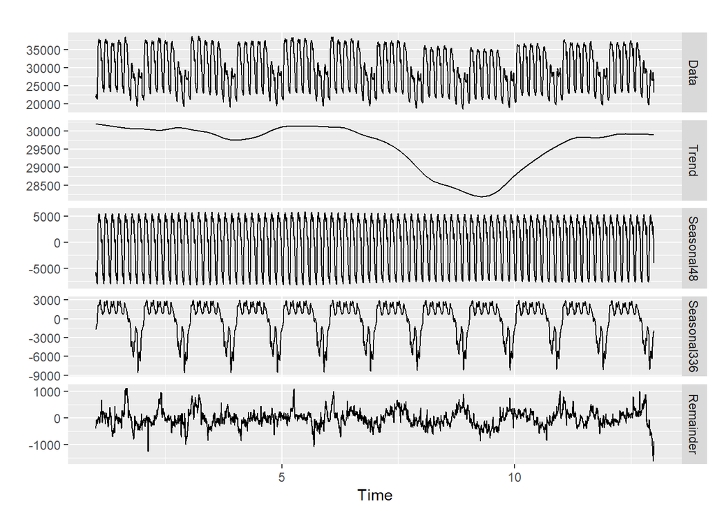

```r
# handles multiple seasonality
mstl(taylor) %>%
  autoplot()
```

## Measuring strength of trend and seasonality

Define the **strength of trend** as:

$$F_T = max \Bigg(0, 1- \frac{Var(R_t)}{Var(T_t + R_t)} \Bigg)$$

- Yields measure between 0 and 1.

Define **strength of seasonality** similarly as:

$$F_S = max \Bigg(0, 1- \frac{Var(R_t)}{Var(S_t + R_t)} \Bigg)$$

A series with seasonal strength $F_S$ close to 0 exhibits almost no seasonality, while a series with strong seasonality will have $F_S$ close to 1.

- These measures are useful to determine series with strong trend or seasonality.

## Forecasting with decomposition

To forecast decomposed time series, components can be foreasted separately.

- *Seasonal component* is usually assumed to be unchanging (or changing extremely slowly): Forecast using seasonal naive method
- *Seasonally adjusted component* can be forecasted with any non-seasonal forecasting method (e.g. random walk with drift, Holt’s method, or a non seasonal ARIMA)

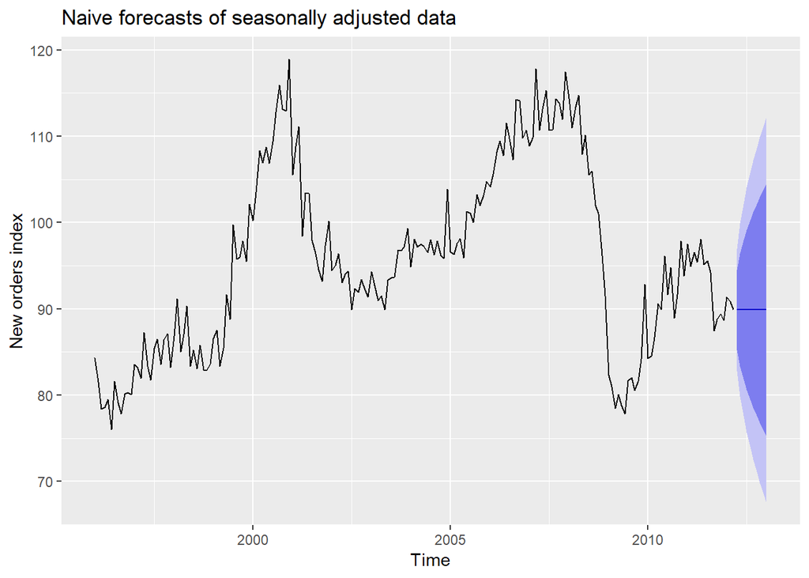

```r
fit <- stl(elecequip,
           t.window = 13,
           s.window = "periodic",
           robust = TRUE)

fit %>%
  seasadj() %>%
  naive() %>%
  autoplot() +
  ylab("New orders index") +
  ggtitle("Naive forecasts of seasonally adjusted data")
```

The figure shows naive forecasts of the seasonally adjusted electrical equipment orders data. These are then “reseasonalised” by adding the seasonal naive forecats of the seasonal component.

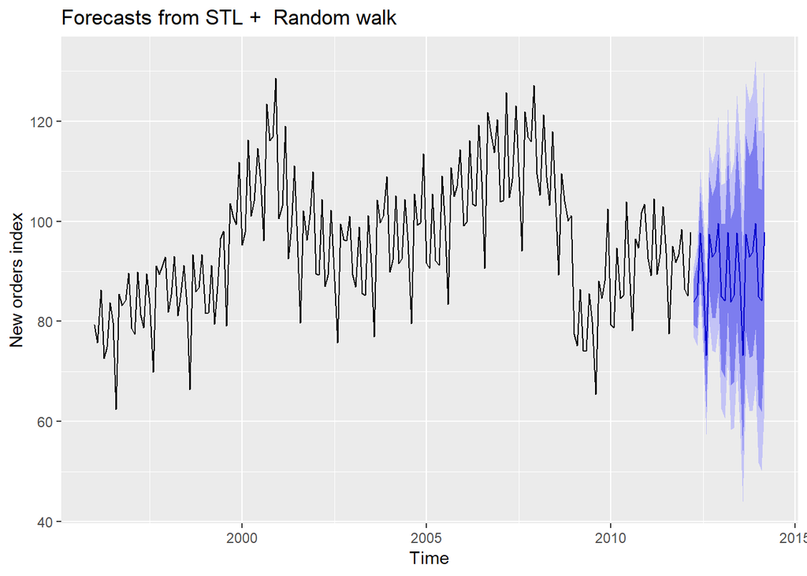

```r
fit %>%
  forecast(method="naive") %>%
  autoplot() + ylab("New orders index")
```

A short-cut approach is to use the `stlf()` function. It will

- decompose the time series using STL
- forecast seasonally adjusted seraies
- return reseasonalized forecasts.

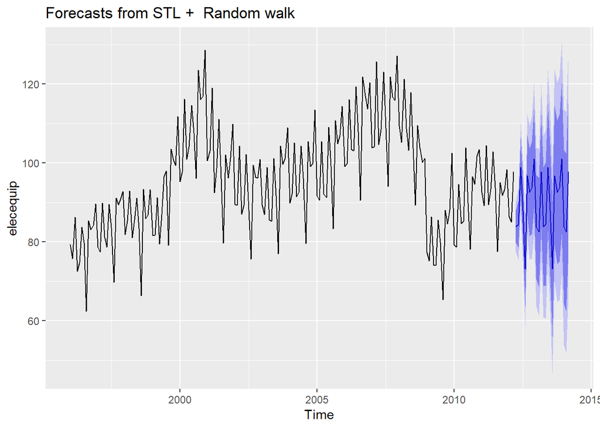

```r
fcast <- stlf(elecequip, method="naive")
autoplot(fcast)
```

## Exercises

#### 2. Data: `plastics`

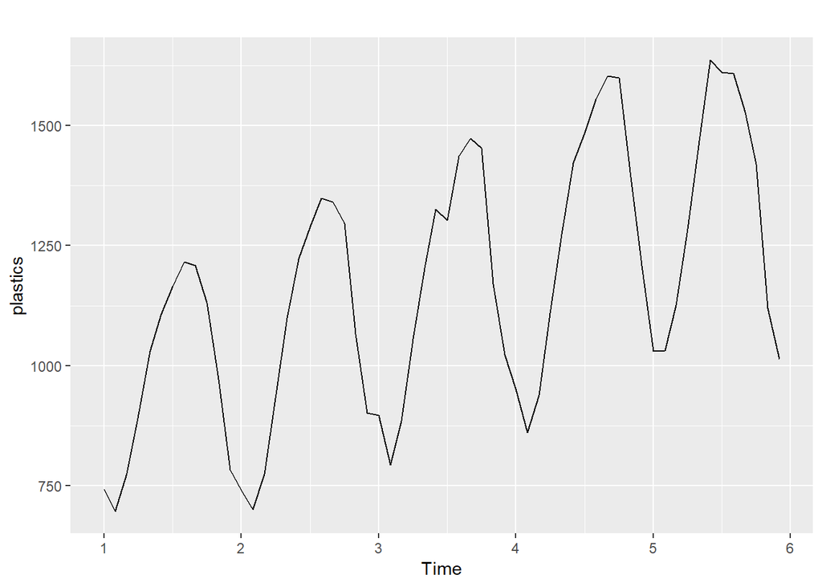

```r
autoplot(plastics)
```

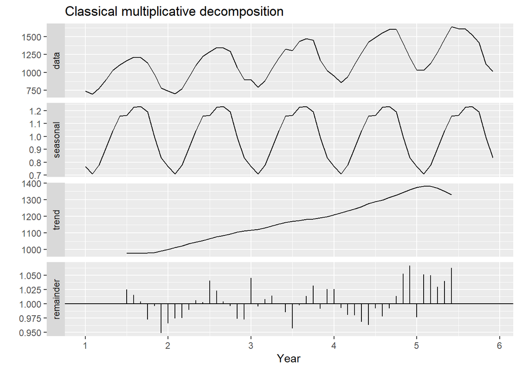

```r
# classical multiplicative decomposition
plastics %>%
  decompose(type="multiplicative") %>%
  autoplot() +
  xlab("Year") +
  ggtitle("Classical multiplicative decomposition")
```

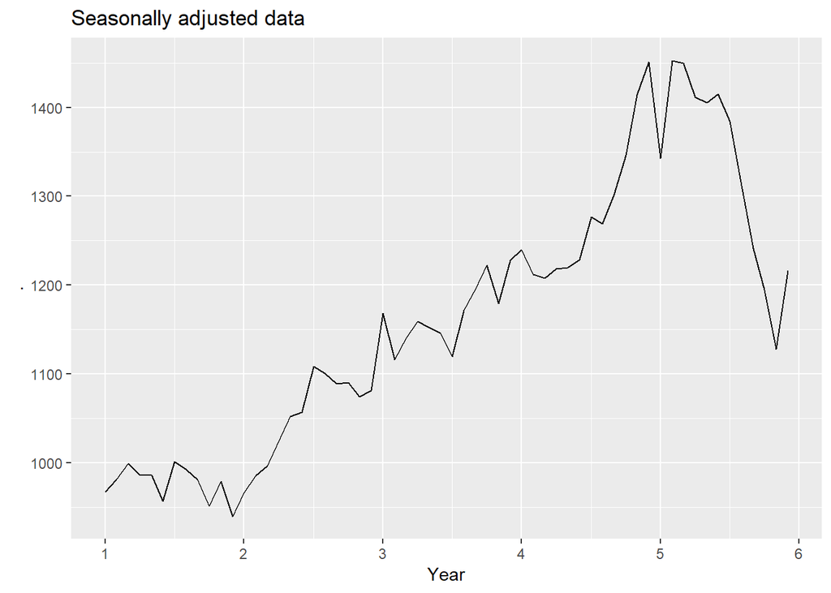

```r
# plot seasonally adjusted data
fit <- decompose(plastics, type="multiplicative")

fit %>%
  seasadj() %>%
  autoplot() +
  xlab("Year") +
  ggtitle("Seasonally adjusted data")
```

#### 3. Data: retail

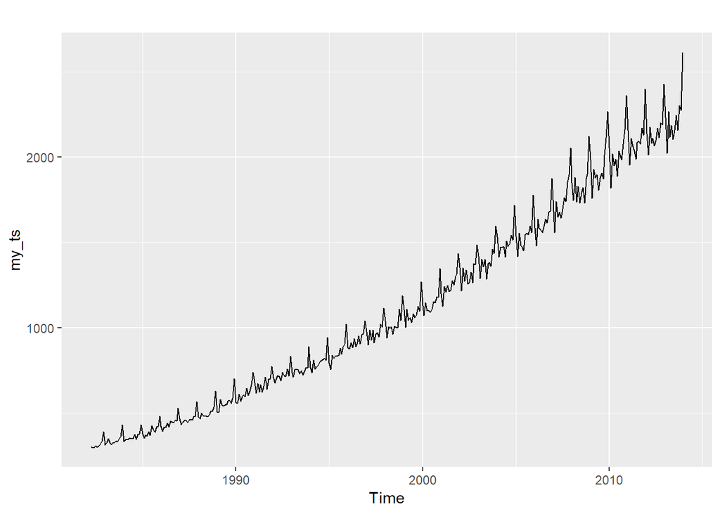

```r
# X11 of retail time series.
# Outliers, unusual features?
retail <- readxl::read_excel("../data/retail.xlsx", skip=1)
my_ts <- ts(retail[,"A3349335T"],
            frequency=12,
            start=c(1982, 4))

autoplot(my_ts)
```

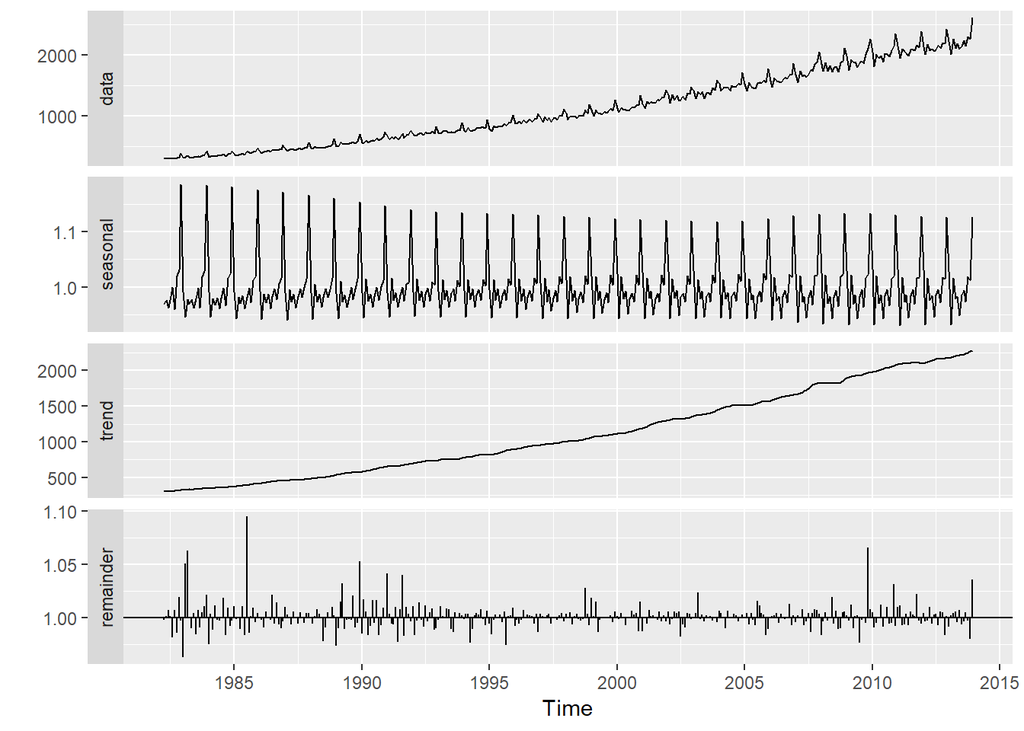

```r
X11_fit <- seas(my_ts, x11 ="")
autoplot(X11_fit)
```

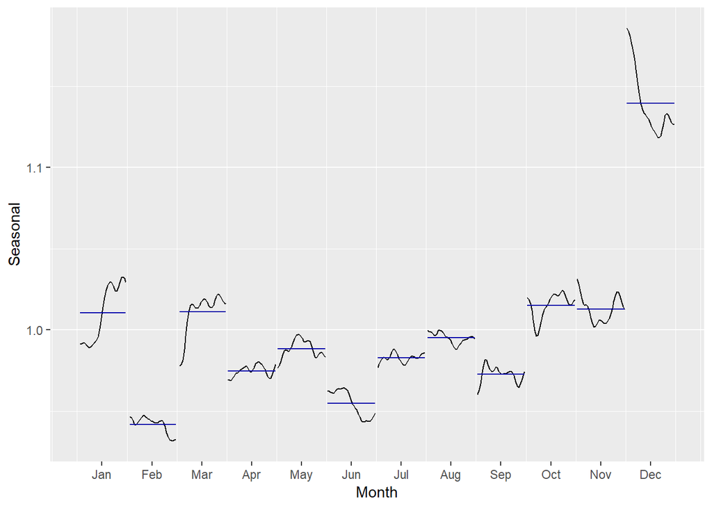

```r
X11_fit %>%
  seasonal() %>%
  ggsubseriesplot() + ylab("Seasonal")
```

#### 5. Data: `cangas`

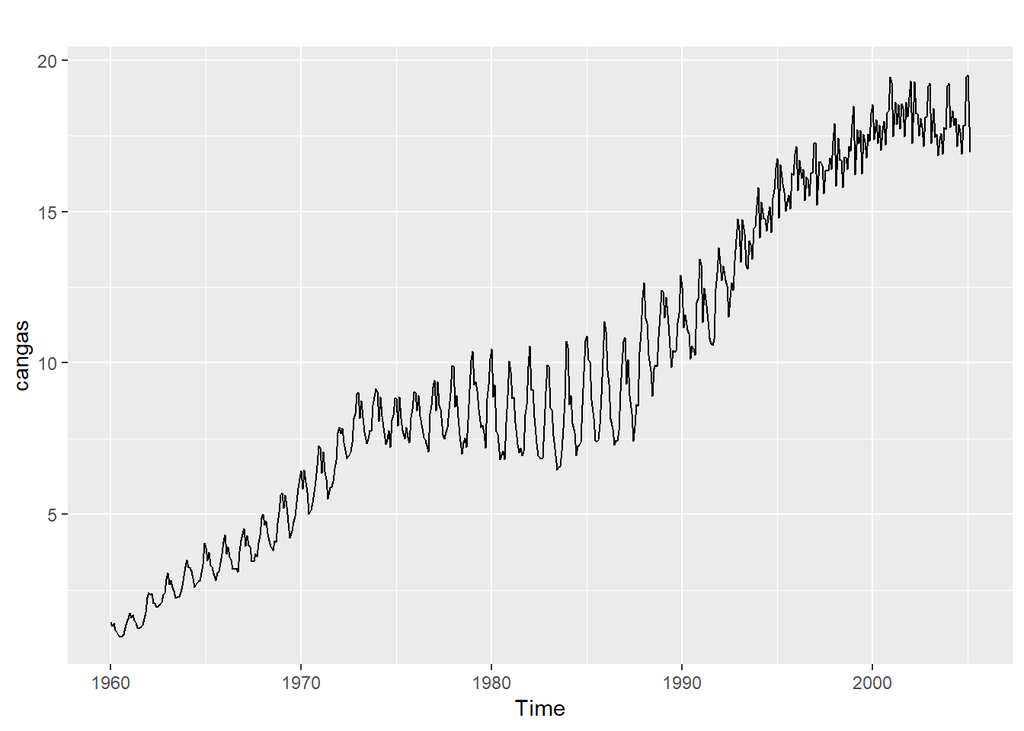

```r
autoplot(cangas)
```

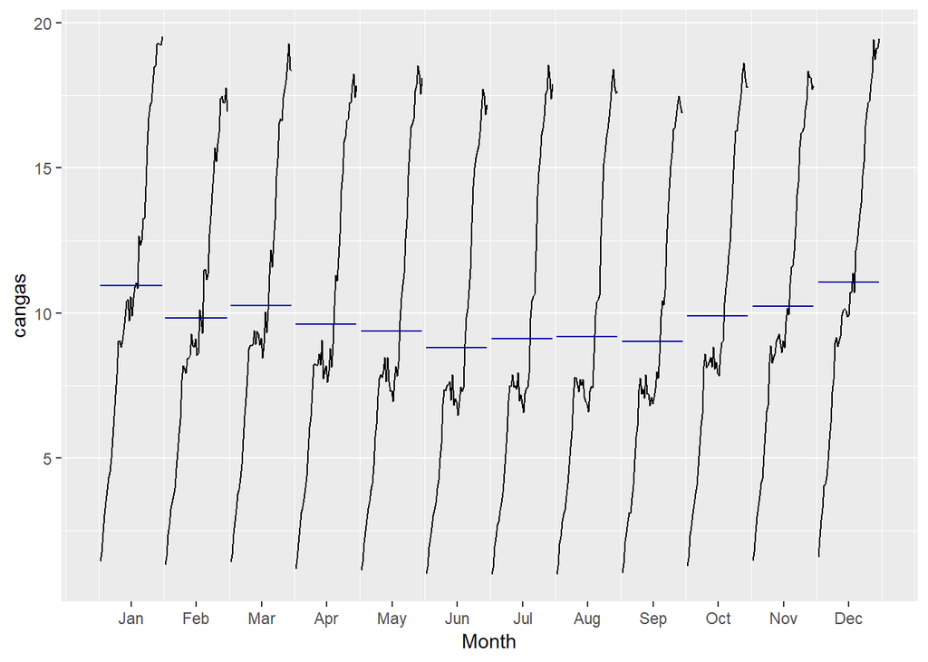

```r
ggsubseriesplot(cangas)
```

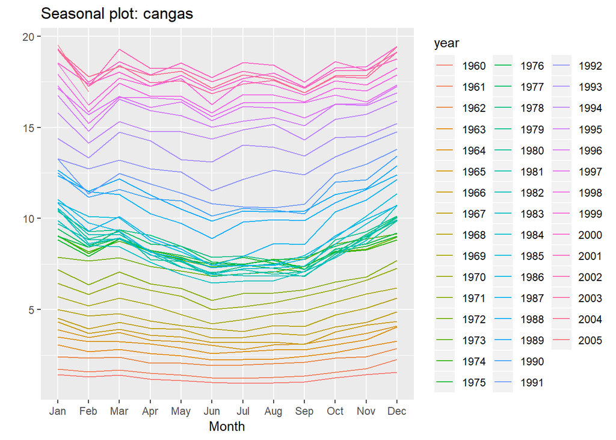

```r
ggseasonplot(cangas)
```

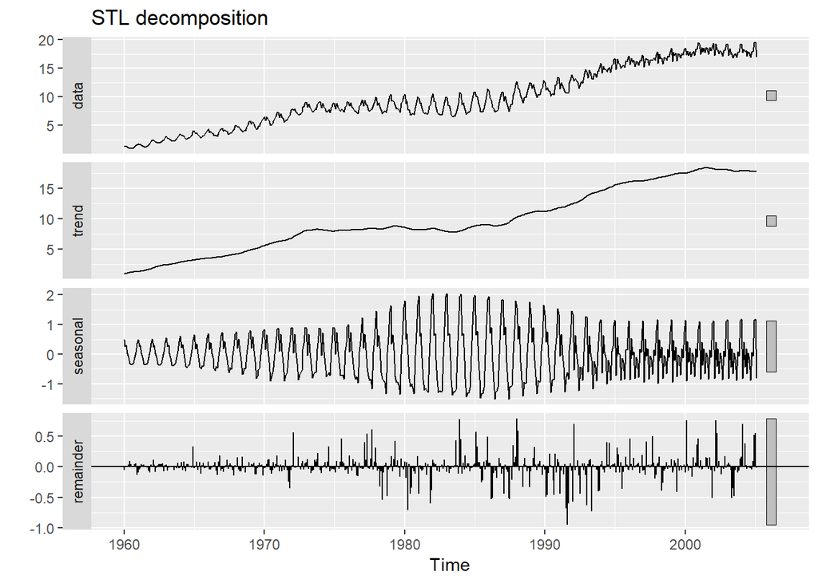

```r
# STL decomposition
cangas %>%
  stl(t.window=13, s.window=7, robust=TRUE)  %>%
  autoplot() + ggtitle("STL decomposition")
```

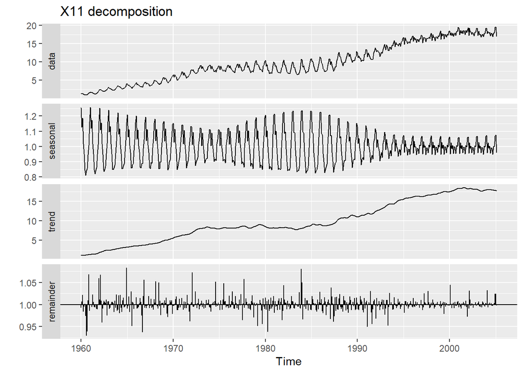

```r
# compare to X11
cangas %>%
  seas(x11="") %>%
  autoplot() + ggtitle("X11 decomposition")
```

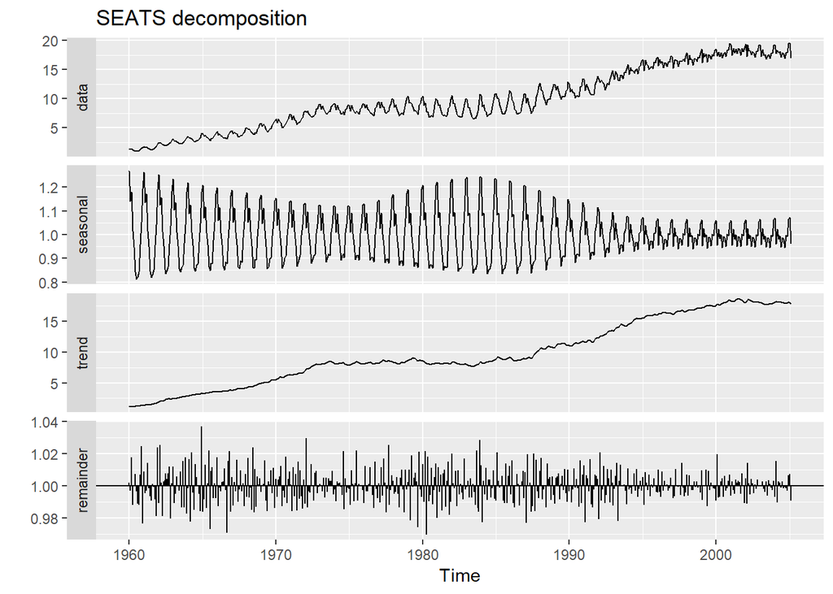

```r
# compare to SEATS
cangas %>%
  seas() %>%
  autoplot() + ggtitle("SEATS decomposition")
```

#### 6. Data: `bricksq`

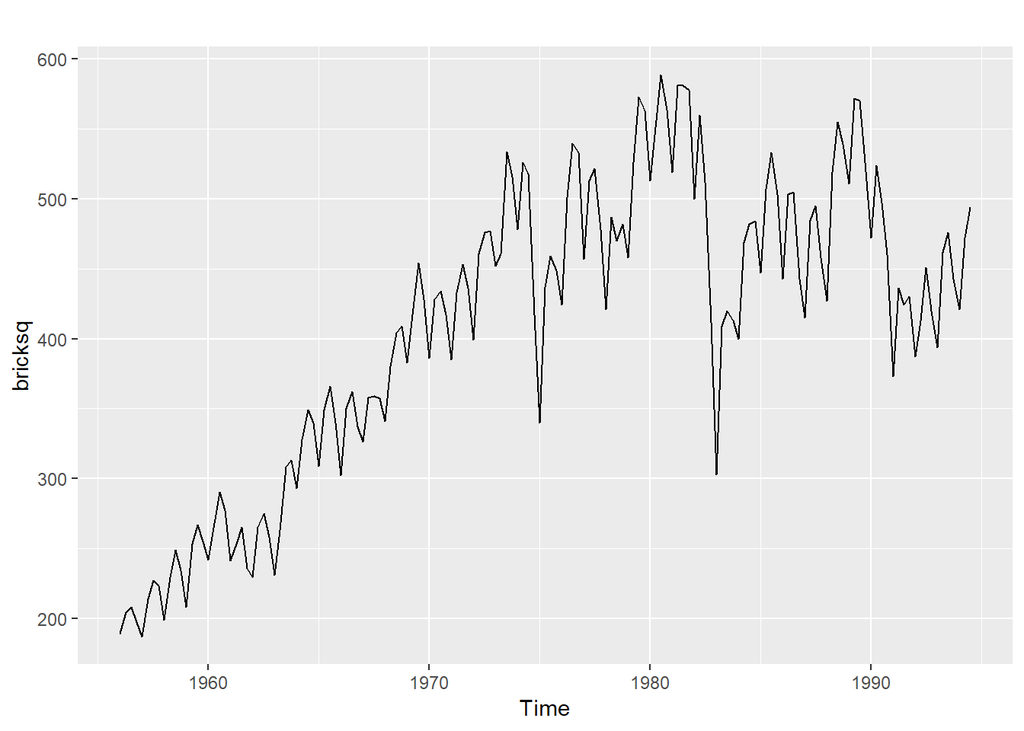

```r
autoplot(bricksq)
```

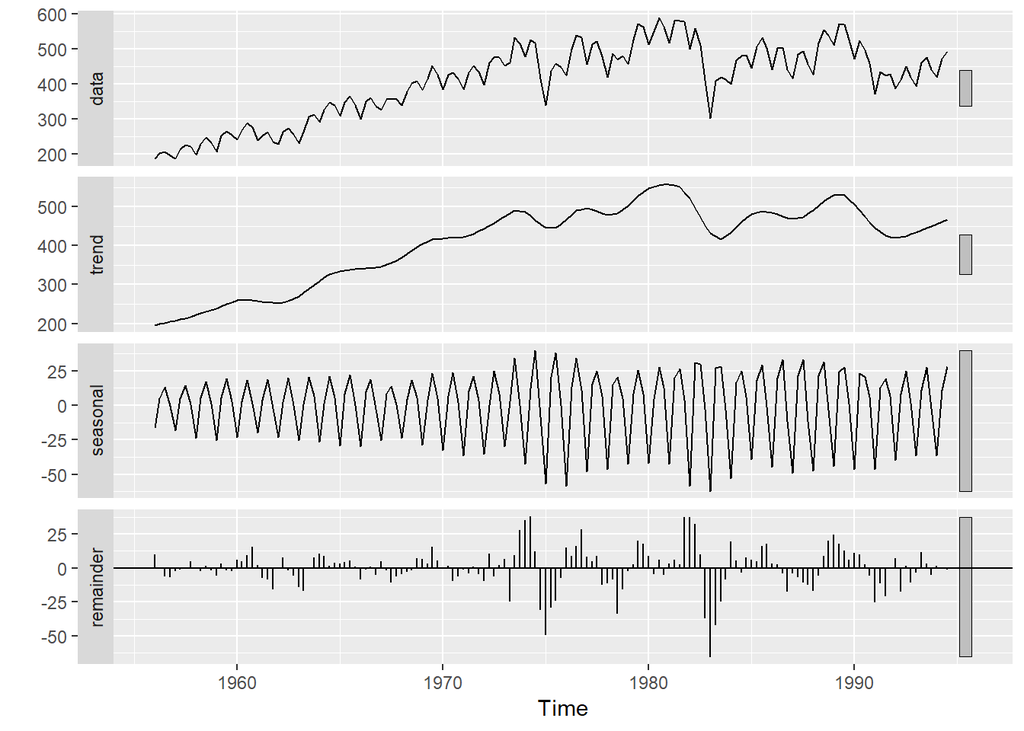

```r
# STL decomposition
bricksq %>%
  stl(t.window=13, s.window=4) -> stl_fit

autoplot(stl_fit)
```

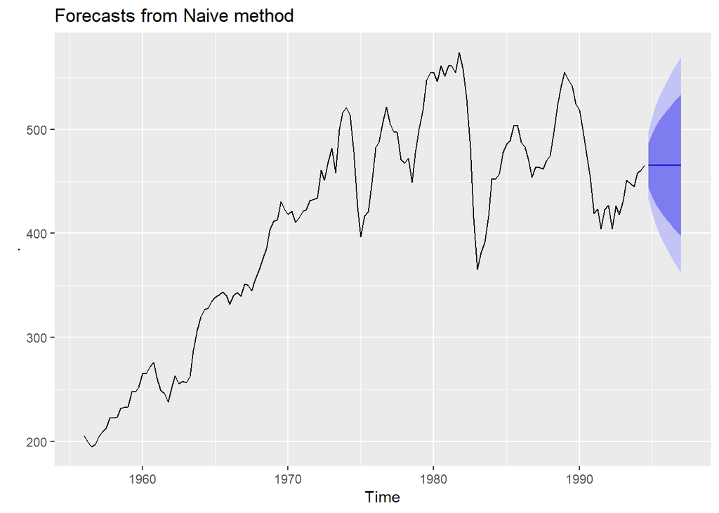

```r
# forecast seasonal adjusted data
seasadj(stl_fit) %>%
  naive() %>%
  autoplot()
```

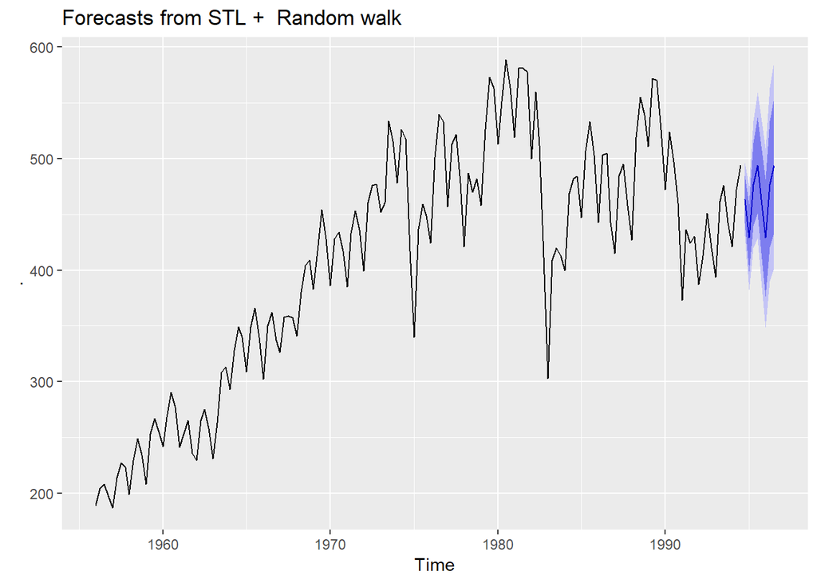

```r
# Reseasonalise
stl_fit %>%
  forecast(method="naive") %>%
  autoplot()
```

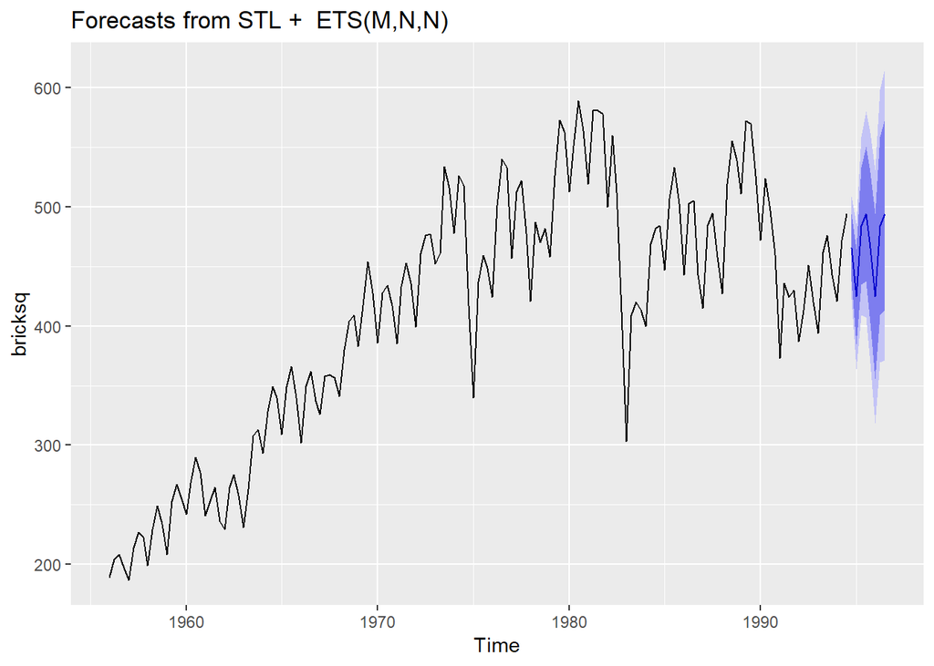

```r
stlf(bricksq) %>%
  autoplot()
```

#### 7. Data=`writing`

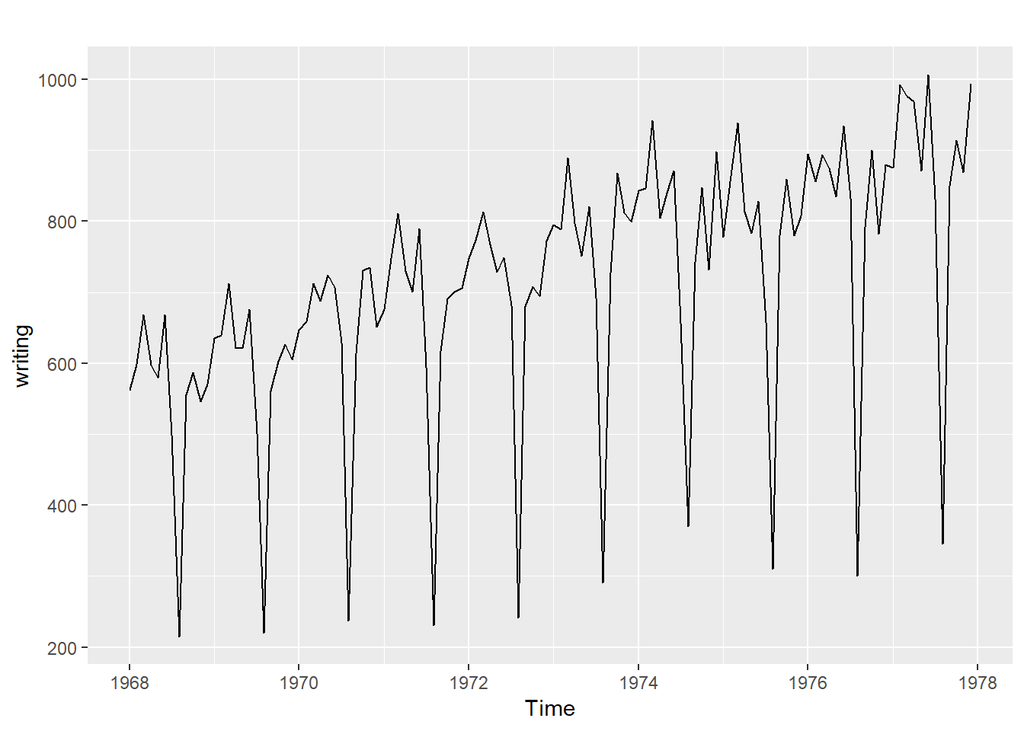

```r
autoplot(writing)
```

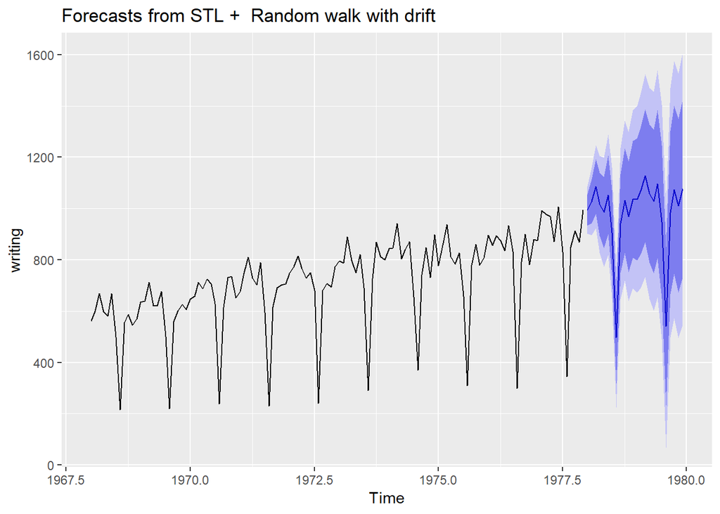

```r
stlf_fit <- stlf(writing, method="rwdrift")
autoplot(stlf_fit)
```